# MIE237

2016-02-23

## regression

## The sum of squares decomposition revisited

\[\begin{align} SST &= \sum_{i=1}^n\left(\hat y_i - \overline y\right)^2 + \sum_{i=1}^n\left(y_i - \hat y_i\right)^2\\ &= SSR + SSE \end{align}\]

They are all sums of squares of normal distributions, so they have \(\chi^2\) distributions with degrees of freedom: \(n-1\), \(1\), and \(n-2\), respectively.

In addition, \(SSR\) and \(SSE\) are independent, so that:\[\frac{SSR/1}{SSE/(n-2)} \sim F_{1, n-2}\]

## Hypothesis test for the slope parameter - revisited

Main hypothesis test: \(H_0:\beta_1=0\) versus \(H_1:\beta_1\ne 0\).

Key fact 1:\[T=\frac{\hat\beta_1 - \beta_1}{\sqrt{MSE}/\sqrt{S_{xx}}}\sim t_{n-2}\]

(And actually *in the case of simple regression* \(T^2 = F\) (algebraically!). The p-value will be *identical*.)

## Example - simulated from 2016-02-02

```
##
## Call:
## lm(formula = y ~ x, data = regr_data)
##
## Residuals:
##     Min      1Q  Median      3Q     Max
## -7.4423 -1.5505  0.5624  1.4499  4.6351
##
## Coefficients:
##             Estimate Std. Error t value Pr(>|t|)
## (Intercept)    4.892      1.295   3.778  0.00138 **
## x              2.647      1.081   2.449  0.02477 *
## ---
## Signif. codes:  0 '***' 0.001 '**' 0.01 '*' 0.05 '.' 0.1 ' ' 1
##
## Residual standard error: 2.787 on 18 degrees of freedom
## Multiple R-squared:   0.25,  Adjusted R-squared:  0.2083
## F-statistic:     6 on 1 and 18 DF,  p-value: 0.02477
```

```
## Analysis of Variance Table
##
## Response: y
##           Df  Sum Sq Mean Sq F value  Pr(>F)
## x          1  46.611  46.611       6 0.02477 *
## Residuals 18 139.832   7.768
## ---
## Signif. codes:  0 '***' 0.001 '**' 0.01 '*' 0.05 '.' 0.1 ' ' 1
```

## Example from 2015 exam (2016-02-05)

```
##
## Call:
## lm(formula = volts ~ max_kpa, data = meters)
##
## Residuals:
##     Min      1Q  Median      3Q     Max
## -2.9328 -0.7438  0.0262  0.6702  3.1693
##
## Coefficients:
##               Estimate Std. Error t value Pr(>|t|)
## (Intercept) -15.761059   1.054718 -14.943   <2e-16 ***
## max_kpa       0.043719   0.004506   9.703   <2e-16 ***
## ---
## Signif. codes:  0 '***' 0.001 '**' 0.01 '*' 0.05 '.' 0.1 ' ' 1
##
## Residual standard error: 1.066 on 398 degrees of freedom
## Multiple R-squared:  0.1913, Adjusted R-squared:  0.1893
## F-statistic: 94.14 on 1 and 398 DF,  p-value: < 2.2e-16
```

## More from 2015 exam

```
## Analysis of Variance Table
##
## Response: volts
##            Df Sum Sq Mean Sq F value    Pr(>F)
## max_kpa     1 106.94 106.940  94.142 < 2.2e-16 ***
## Residuals 398 452.11   1.136
## ---
## Signif. codes:  0 '***' 0.001 '**' 0.01 '*' 0.05 '.' 0.1 ' ' 1
```

Note that the \(T^2 = F\) is a bit of mathematcal trivia that applies in simple regression only.

## New topic: \(R^2\)

The "fit" of a linear model can be summarized by a single number (!):

\[\begin{align*} SST &= SSR + SSE \\ 1 &= \frac{SSR}{SST} + \frac{SSE}{SST}\\ R^2 &= \frac{SSR}{SST}\end{align*}\]

This is a moderately useful number that also goes by a unfortunately dramatic-sounding "coefficient of determination" and can be interpreted as "the proportion of variation explained by the model".

But in the end it is just a single number that summarizes an *entire bivariate linear relationship*, so don't take it too seriously.

## More examples

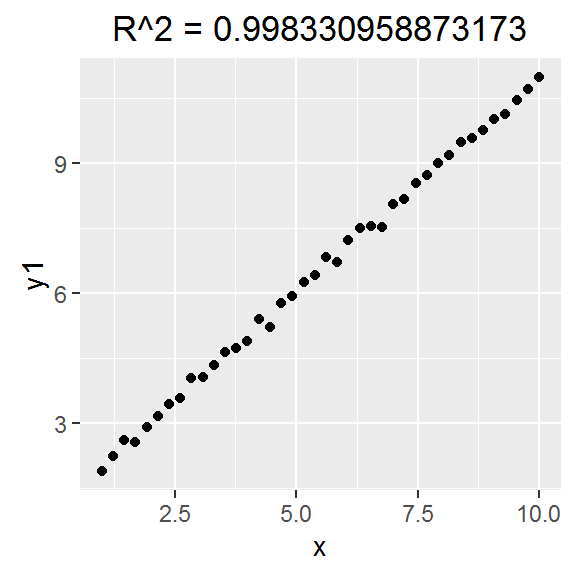

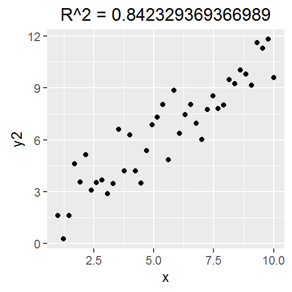

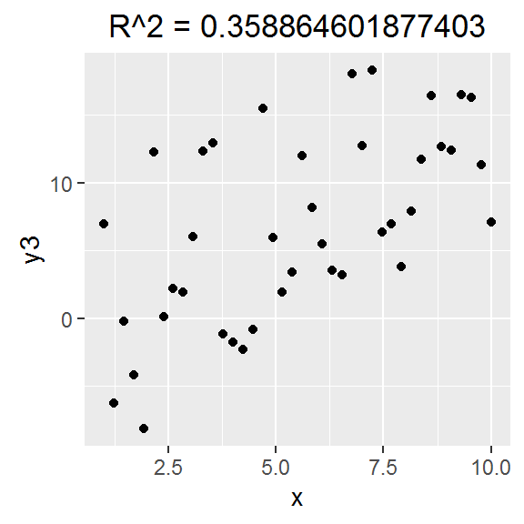

## Limitations: "Model assumptions"

Assumes linear model is appropriate to begin with.

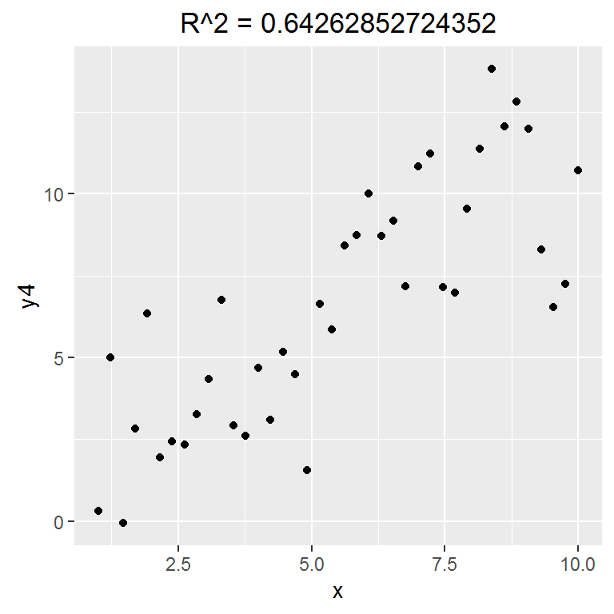

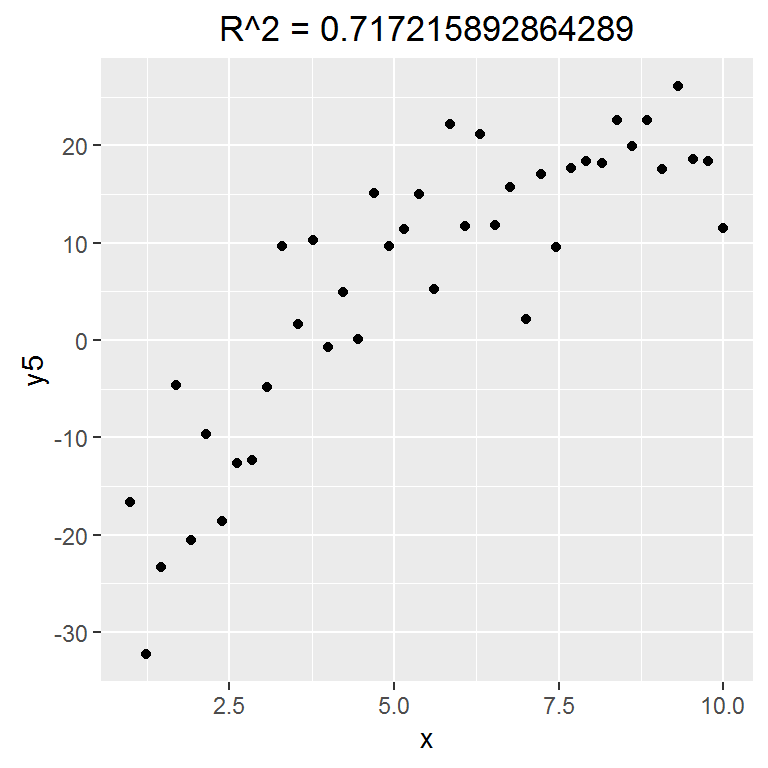

## Limitations: sample size